# Enron Person of Interest Project

## 1. Overview

*Question 1. Summarize for us the goal of this project and how machine learning is useful in trying to accomplish it.* The project tries to predict the people involved in the Enron scheme, ‘persons of interest’. Machine learning uses information about financial benefits and email communications, trying to figuring out patterns that distinguished the people of interests versus the rest. The dataset given includes individual’s information on financial benefits (payments and stock) involved with the company and email communications. It is obvious that the financial information will be useful for identifying people involved since money is the motive of the scheme. Individuals with especially high rate of communication the people of interests are likely to be one.

**Note:**

- Since this is a small dataset, I decided to run many grid-searched model. However, if you want to know the end of the movie, I find the model that applies principle component and logistic regression works best.
- This is a project for my Data Science course at Udacity, and the code for feature_format.py(except for a few edits by me) and tester.py is written by Udacity

```python
#Setting up the environment
#!/usr/bin/python

import sys
import pickle
sys.path.append("../tools/")
import numpy as np
import pandas as pd
import matplotlib.pyplot as plt
%matplotlib inline
from feature_format import featureFormat, targetFeatureSplit
from tester import dump_classifier_and_data, test_classifier
from sklearn.feature_selection import SelectKBest, f_classif
from sklearn.cross_validation import train_test_split

### features_list is a list of strings, each of which is a feature name.
### Task 1: Select what features you'll use.
### The first feature must be "poi".


### Load the dictionary containing the / m.
with open("final_project_dataset.pkl", "r") as data_file:
    data_dict = pickle.load(data_file)
    data = pd.DataFrame.from_dict(data_dict,orient='index', dtype=np.float).drop('email_address',1)

# Remove irrelevant outliers
#data = data[~(data.index == 'TOTAL')]
print 'There are %i pois out of %i samples.' %(sum(data['poi']==1),len(data['poi']))

# Summary of missing values across features:
print data.isnull().sum(axis = 0)
```

```
There are 18 pois out of 146 samples.
salary                        51
to_messages                   60
deferral_payments            107
total_payments                21
exercised_stock_options       44
bonus                         64
restricted_stock              36
shared_receipt_with_poi       60
restricted_stock_deferred    128
total_stock_value             20
expenses                      51
loan_advances                142
from_messages                 60
other                         53
from_this_person_to_poi       60
poi                            0
director_fees                129
deferred_income               97
long_term_incentive           80
from_poi_to_this_person       60
dtype: int64
```

## 2. Feature Engineering

*Question 2. What features did you end up using in your POI identifier, and what selection process did you use to pick them? Did you have to do any scaling? Why or why not?*

I ended up keeping the features: "shared_receipt_with_poi","exercised_stock_options", and "from_frac". My strategy of choosing predictors is to run ANOVA F-value for each feature in 1500 times stratified resampling (to take care of possible overfitting) and choosing the ones with the best scores from each category: payment, stock value, and email communication. I narrowed down to some set of features(see below), and the set of these 3 features yields the highest performance.

I added 3 new variables:

- ‘from_frac’, ‘to_frac’: proportion of to/ from emails of a person sent from/to a poi. The motivation is that pois may communicate with each other much more frequently. The idea is also stemmed from one of the lesson videos of Udacity. As you will see below, 'from_frac' has the highest performance and turns out to be one of the key features; removing it drives the recall down though slightly increases precision. 'to_frac' is in the feature group that has better scores. However, adding 'to_frac' has near zero effect on recall and drives down the precision.
- ‘total_money’: I added this variable because in case the pois try to hide their financial benefits by diversifying the way they receive the money, then this sum may tell information that the individuals features don’t. This feature, however, has a middle-range performance score. Adding this feature decreases the model's performance in terms of both precion and recall. Please a table below for the effect of these features.

```python
### Create new features: ‘from_frac’, ‘to_frac', and 'total_money':

data = data.fillna(0)

data['to_frac'] = data["from_poi_to_this_person"]/data["to_messages"]
data['from_frac'] = data["from_this_person_to_poi"]/data["from_messages"]
data['total_money'] = data['total_payments'] + data["total_stock_value"]
data = data.fillna(0)

# Convert the dataset to dictionary for later submission:
my_dataset = data.to_dict(orient = 'index')
```

```
Variable Importance Chart
                      Feature P-value  Score
0                      salary    0.85   1.92
1                 to_messages    0.23   1.73
2           deferral_payments    0.64   0.23
3              total_payments    0.52   1.21
4     exercised_stock_options    0.62   2.73
5                       bonus    0.73   2.27
6            restricted_stock    0.78   0.99
7     shared_receipt_with_poi    0.01   8.20
8   restricted_stock_deferred    0.89   0.05
9           total_stock_value    0.66   2.61
10                   expenses    0.79   0.65
11              loan_advances    0.17   2.80
12              from_messages    0.72   0.17
13                      other    0.71   0.52
14    from_this_person_to_poi    0.19   2.49
15              director_fees    0.45   0.64
16            deferred_income    0.62   1.41
17        long_term_incentive    0.81   1.11
18    from_poi_to_this_person    0.04   5.18
19                    to_frac    0.10   3.16
20                  from_frac    0.00  15.45
21                total_money    0.60   2.00
```

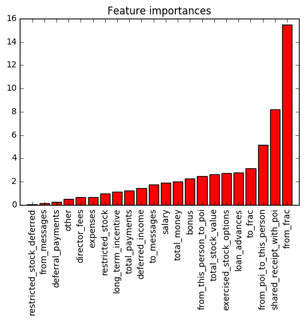

```python
### Investigate Variable Importance:

select = SelectKBest(k = 'all')

from sklearn.cross_validation import StratifiedShuffleSplit
labels = data['poi']
features = data.drop('poi',axis = 1)

# SelectKBest with multiple resamplings:
from sklearn.cross_validation import StratifiedShuffleSplit
cv = StratifiedShuffleSplit(labels, 1500, random_state = 42)
score = []
pval = []
for train_idx, test_idx in cv:
    features_train = features.iloc[train_idx,:]
    labels_train = labels[train_idx]
    select.fit(features_train,labels_train)
    score.append(select.scores_)
    pval.append(select.pvalues_)

avgscore = np.mean(score, axis = 0)
avgpval = np.mean(pval, axis = 0)


print "Variable Importance Chart"
print pd.DataFrame(
    {'Feature': features.columns,
     'Score': [ '%.2f' % elem for elem in avgscore],
     'P-value': [ '%.2f' % elem for elem in avgpval]
    })

indices = np.argsort(avgscore)

plt.figure()
plt.title("Feature importances")
plt.bar(range(len(avgscore)), avgscore[indices],
       color="r", align="center")
plt.xticks(range(len(avgscore)), features.columns[indices],rotation=90)
plt.xlim([-1, len(avgscore)])
plt.show()
```

# Model building and Evaluation

*Question 3. What algorithm did you end up using? What other one(s) did you try? How did model performance differ between algorithms?*

** Model Performance Summary

[output not shown]

```python
# Sets of features to train on:
feature_list1 = ['to_messages','shared_receipt_with_poi','loan_advances','from_this_person_to_poi',
             'from_poi_to_this_person','to_frac','from_frac'] # features with p-val < 0.3
feature_list2 = ['from_frac','shared_receipt_with_poi','exercised_stock_options']
feature_list21 = feature_list2 + ['total_money'] # adding 'total_money'
feature_list22 = feature_list2 + ['to_frac'] # adding 'to_frac'
feature_list23 = ['shared_receipt_with_poi','exercised_stock_options'] # removing 'from_frac'


feature_use = feature_list2 #Replace feature set to run on

features = data[feature_use]
features_list = ['poi'] + feature_use


from sklearn.neighbors import KNeighborsClassifier
clf_kn = KNeighborsClassifier()
from sklearn.tree import DecisionTreeClassifier
clf_dectree = DecisionTreeClassifier(class_weight = 'balanced',random_state = 111)
from sklearn.linear_model import LogisticRegression
clf_log = LogisticRegression(class_weight = 'balanced',random_state = 111)
from sklearn.ensemble import RandomForestClassifier
clf_rf = RandomForestClassifier(class_weight = 'balanced',random_state = 111)


from sklearn.preprocessing import MinMaxScaler
from sklearn.grid_search import GridSearchCV
from sklearn.decomposition import PCA
from sklearn.pipeline import Pipeline
pca = PCA()
n_compnt = range(len(feature_use)) + [3]
n_compnt.remove(0)


pipe_kn = Pipeline(steps = [('pca',pca),('scale',MinMaxScaler()),('kn',clf_kn)])
param_grid_kn = dict(pca__n_components = n_compnt,
                     kn__n_neighbors = [3,5,7,11],
                     kn__weights = ['uniform','distance'])
grid_search_kn = GridSearchCV(pipe_kn, param_grid_kn, scoring = 'recall')
grid_search_kn.fit(features,labels)
test_classifier(grid_search_kn.best_estimator_,my_dataset,features_list)


pipe_log = Pipeline(steps = [('pca',pca),('clf',clf_log)])
param_grid_log = dict(pca__n_components = n_compnt,
                      clf__C = [0.0003,0.001,0.003,0.01,0.03,0.1,0.3,1,3])
grid_search_log = GridSearchCV(pipe_log,param_grid_log,scoring = 'recall')
grid_search_log.fit(features,labels)
test_classifier(grid_search_log.best_estimator_,my_dataset,features_list)

pipe_dectree = Pipeline(steps = [('pca',pca),('clf',clf_dectree)])
param_grid_dectree = dict(pca__n_components = n_compnt,
                          clf__max_depth = [1,2,3,5,7])
grid_search_dectree = GridSearchCV(pipe_dectree,param_grid_dectree,scoring = 'recall')
grid_search_dectree.fit(features,labels)
test_classifier(grid_search_dectree.best_estimator_,my_dataset,features_list)

pipe_rf = Pipeline(steps = [('pca',pca),('clf',clf_rf)])
param_grid_rf = dict(pca__n_components = n_compnt,
                     clf__max_depth = [1,2,3,5,7])
grid_search_rf = GridSearchCV(pipe_rf,param_grid_rf,scoring = 'recall')
grid_search_rf.fit(features,labels)
test_classifier(grid_search_rf.best_estimator_,my_dataset,features_list)
```

```
Pipeline(steps=[('pca', PCA(copy=True, n_components=3, whiten=False)), ('scale', MinMaxScaler(copy=True, feature_range=(0, 1))), ('kn', KNeighborsClassifier(algorithm='auto', leaf_size=30, metric='minkowski',
           metric_params=None, n_jobs=1, n_neighbors=5, p=2,
           weights='uniform'))])
	Accuracy: 0.82092	Precision: 0.29602	Recall: 0.11900	F1: 0.16976	F2: 0.13517
	Total predictions: 13000	True positives:  238	False positives:  566	False negatives: 1762	True negatives: 10434

Pipeline(steps=[('pca', PCA(copy=True, n_components=2, whiten=False)), ('clf', LogisticRegression(C=0.0003, class_weight='balanced', dual=False,
          fit_intercept=True, intercept_scaling=1, max_iter=100,
          multi_class='ovr', n_jobs=1, penalty='l2', random_state=111,
          solver='liblinear', tol=0.0001, verbose=0, warm_start=False))])
	Accuracy: 0.70185	Precision: 0.32681	Recall: 0.88500	F1: 0.47735	F2: 0.65966
	Total predictions: 13000	True positives: 1770	False positives: 3646	False negatives:  230	True negatives: 7354

Pipeline(steps=[('pca', PCA(copy=True, n_components=2, whiten=False)), ('clf', DecisionTreeClassifier(class_weight='balanced', criterion='gini', max_depth=3,
            max_features=None, max_leaf_nodes=None, min_samples_leaf=1,
            min_samples_split=2, min_weight_fraction_leaf=0.0,
            presort=False, random_state=111, splitter='best'))])
	Accuracy: 0.78754	Precision: 0.37749	Recall: 0.58700	F1: 0.45949	F2: 0.52835
	Total predictions: 13000	True positives: 1174	False positives: 1936	False negatives:  826	True negatives: 9064

Pipeline(steps=[('pca', PCA(copy=True, n_components=3, whiten=False)), ('clf', RandomForestClassifier(bootstrap=True, class_weight='balanced',
            criterion='gini', max_depth=1, max_features='auto',
            max_leaf_nodes=None, min_samples_leaf=1, min_samples_split=2,
            min_weight_fraction_leaf=0.0, n_estimators=10, n_jobs=1,
            oob_score=False, random_state=111, verbose=0, warm_start=False))])
	Accuracy: 0.73762	Precision: 0.32437	Recall: 0.65150	F1: 0.43311	F2: 0.54215
	Total predictions: 13000	True positives: 1303	False positives: 2714	False negatives:  697	True negatives: 8286
```

*Question 4. What does it mean to tune the parameters of an algorithm, and what can happen if you don’t do this well? How did you tune the parameters of your particular algorithm?*

Tuning parameters of an algorithm means selecting the set of parameters to optimize the performance of the algorithm. If tuning parameters isn’t done properly, the model may overfit or underfit.

*5. What is validation, and what’s a classic mistake you can make if you do it wrong? How did you validate your analysis?*

Validation is evaluating the performance of the model on new data. Without validation, it is very easy to choose an overfitting model that performs very well on known data but poorly on new data. I employ validation in my use of grid search with cross validation and my use of test_classifier of tester.py, which uses stratified shuffle split cross validator.

# 4. Evaluation

*6. Give at least 2 evaluation metrics and your average performance for each of them. Explain an interpretation of your metrics that says something human-understandable about your algorithm’s performance.*

The precision and recall of my model is 32% and 89% respectively. This means that my algorithm predicts a ‘poi’ accurately 32% of the times; of all people predicted as a ‘poi’, 32% are actually ‘pois’. The recall suggests that my model is able to identify 89% of ‘pois’.

```python
clf = grid_search_log.best_estimator_
dump_classifier_and_data(clf, my_dataset, features_list)
```